# CIS-544-hw4-chen

Chen

November 20, 2016

## Problem 1

Principal components regression (PCR) can be performed using the `pcr()` function, part of `pls` library. We will apply PCR to the `Hitters` data, in order to predict `Salary`. Make sure that missing values have been removed from the data.

```r
library(ISLR) ## load the "ISLR" Library, which has the Hitters Dataset.
library(pls)  ## load the "pls" library, which has the Principal components regression function.
set.seed(7)
# new data frame with no missing values
pcr.model = pcr(Salary ~ . , data = Hitters, scale = TRUE, validation = "CV")
pcr.model    # Perform Principal components regression to Hitters data, salary respond to others variable.
```

```
## Principal component regression , fitted with the singular value decomposition algorithm.
## Cross-validated using 10 random segments.
## Call:
## pcr(formula = Salary ~ ., data = Hitters, scale = TRUE, validation = "CV")
```

Setting `scale=TRUE` has the effect of standardizing each predictor prior to generating the principal components, so that the scale on which each variable was measured does not have an effect. Setting `validation="CV"` causes `pcr()` to compute 10-fold cross validation error for each possible value of $K$, the number of principal components used.

```r
set.seed(11)  ## set up a random number seed.
folds=sample(rep(1:10,length=nrow(Hitters)))  ## create the 10-fold cross validation.
folds  ## Display
```

```
##   [1] 10  1  4  5  1  3  8  2  7  9  5  8  2  3  7  7  8  1  8  6  2  5 10
##  [24]  5  9  4  9  9  7  7  6  6 10  9  5  5 10 10  3  7 10  1  9  3  5 10
##  [47]  7  4  5  8  7  2  5  4 10  6 10  7  3  8  6  7  6  1  4  7  5  8  9
##  [70]  7  3  7  1  1  3  3  7  2  9  4  3 10  2  7  8 10 10  3  1  3  5  6
##  [93]  5  6  7  2  2  4  2 10  5 10  2 10  6  8  1 10  1  1  6  8  8  2 10
## [116]  3  2 10 10  3 10  9  9  4  9  6  6  8  2  4  4  1  1  7  7  1  9  4
## [139]  3  2  3  2  5  4  2  4  4  5  2  8  7  4  2 10  4  8  4  3  7  3  7
## [162]  4  9 10  5  7  9  8  8  6 10  5  1  6  3  1  4  3 10  2  6  2  2  6
## [185]  5  8  8  3  7  4  1  8  8  9  3  3  7  4 10  4  9  4  2  5  6  4  6
## [208]  8  3  8  1  6  6  5  5  2  1  3  7  7 10  3  5  1  6  5  2  4  5  6
## [231]  6 10  5  6  8  3  4 10  8  2  1  5 10  1  2  3  2  4  2  7  6 10  9
## [254]  2  2  5  8  6  9  8  1  8  9  5  4  8  5  7  1  6  7  6  1  1  1  9
## [277]  8  3  1  9  1  9  7  9  9  6  4  6  9  1  3  8  4 10  2  7  8 10  3
## [300]  6  6  4  1  9  3  9  3  1  4  9  7  9  5  5  9  8  5  1  9  2  2  9
```

```r
table(folds)  ## make a summary for the 10-fold cross validation to a table.
```

```
## folds
##  1  2  3  4  5  6  7  8  9 10
## 33 33 32 32 32 32 32 32 32 32
```

```r
summary(folds)  ## summary for the 10-fold cross validation, which show the min, max,median,and mean value.
```

```
##    Min. 1st Qu.  Median    Mean 3rd Qu.    Max.
##   1.000   3.000   5.000   5.475   8.000  10.000
```

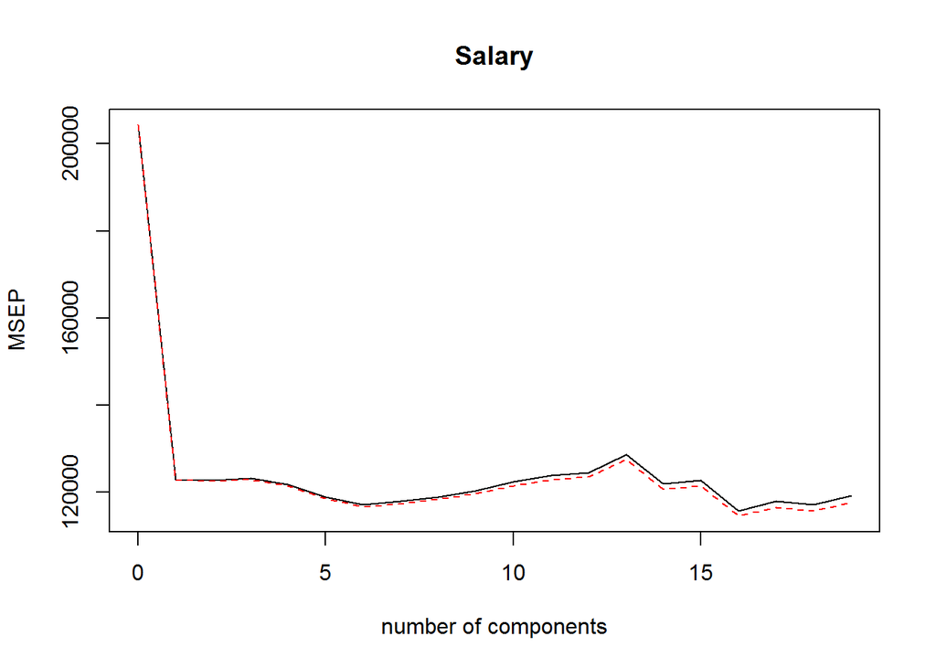

```r
validationplot(pcr.model, val.type = "MSEP")  ## make the validationplot for Principal components regression model.
```

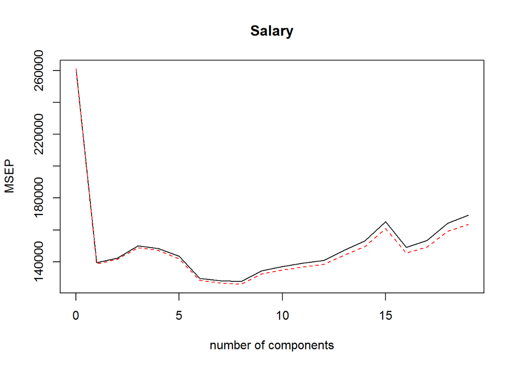

```r
# Create test and train data Predict Salary on the Hitters
# data
x = model.matrix(Salary ~ ., Hitters)[, -1]
y = Hitters$Salary
set.seed(1)
train = sample(1:nrow(x), nrow(x)/2)
test = (-train)
y.test = y[test]
set.seed(1)
# PCR on the training data
pcr.fit = pcr(Salary ~ ., data = Hitters, subset = train, scale = TRUE,
validation = "CV")
validationplot(pcr.fit, val.type = "MSEP")
```

### Problem 2

In this problem we look at the data set `swiss` describing fertility in Switzerland in 1888.

Type `?swiss` in the command line (console), and give a brief description of this dataset. Fertility (number of children a woman gives birth to over the course of her life) is high in developing countries and low in developed nations. Type `names(swiss)` to get a list of the variables in this dataset.

Use the library `leaps` to perform best subset selection, with the function `regsubsets` considering `Fertility` as a function of all variables.

```r
library(leaps)  ## Load the 'leaps' Dataset which has the swiss Dataset.
regfit.full=regsubsets(Fertility~.,data=swiss)    # Perform best subsets selection using `regsubsets` considering all variables, Fertility repond to other variable.
summary(regfit.full)  ##Display which contain * is most important.
```

```
## Subset selection object
## Call: regsubsets.formula(Fertility ~ ., data = swiss)
## 5 Variables  (and intercept)
##                  Forced in Forced out
## Agriculture          FALSE      FALSE
## Examination          FALSE      FALSE
## Education            FALSE      FALSE
## Catholic             FALSE      FALSE
## Infant.Mortality     FALSE      FALSE
## 1 subsets of each size up to 5
## Selection Algorithm: exhaustive
##          Agriculture Examination Education Catholic Infant.Mortality
## 1  ( 1 ) " "         " "         "*"       " "      " "
## 2  ( 1 ) " "         " "         "*"       "*"      " "
## 3  ( 1 ) " "         " "         "*"       "*"      "*"
## 4  ( 1 ) "*"         " "         "*"       "*"      "*"
## 5  ( 1 ) "*"         "*"         "*"       "*"      "*"
```

```r
regfit.full=regsubsets(Fertility~.,data=swiss,nvmax = 5)# Run best subset with all 5 variables
reg.summary=summary(regfit.full)
names(reg.summary)
```

```
## [1] "which"  "rsq"    "rss"    "adjr2"  "cp"     "bic"    "outmat" "obj"
```

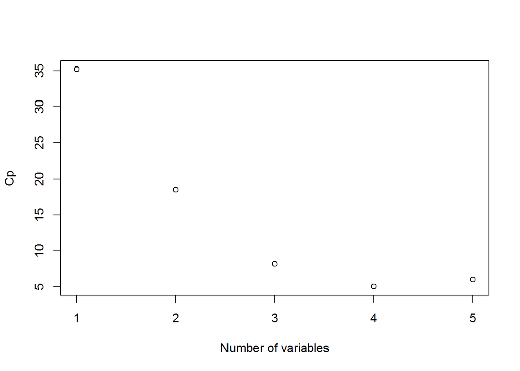

```r
plot(reg.summary$cp,xlab = "Number of variables", ylab = "Cp")  ## Plot the Cp component (estimate of predicted error) of
```

```r
which.min(reg.summary$cp)  ## reg.summary
```

```
## [1] 4
```

Question: why points(4,reg.summary$cp[4],pch=5,col=“red”) have some error?

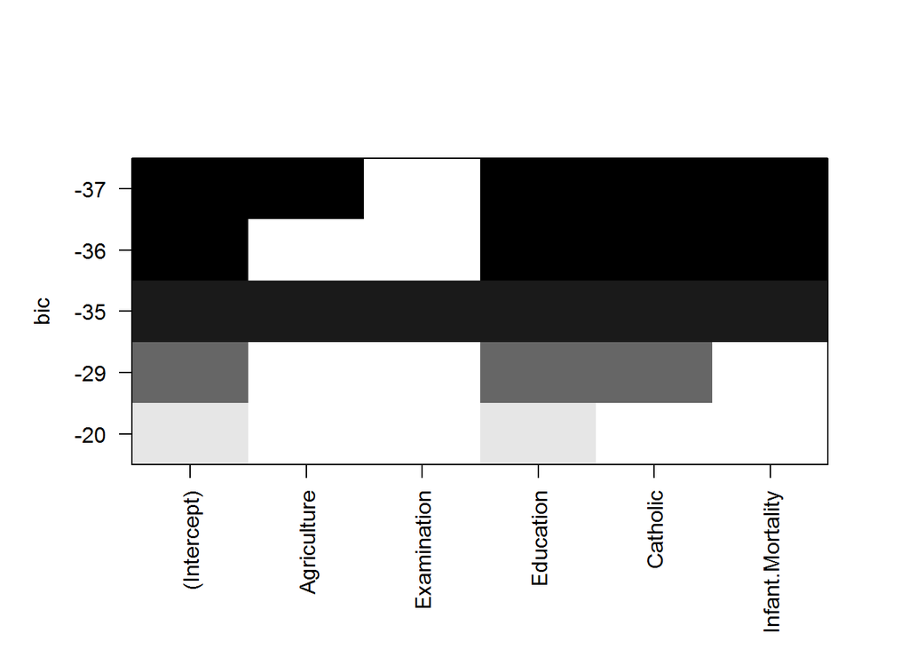

```r
plot(regfit.full,scalp="Cp")
```

```r
coef(regfit.full,5)
```

```
##      (Intercept)      Agriculture      Examination        Education
##       66.9151817       -0.1721140       -0.2580082       -0.8709401
##         Catholic Infant.Mortality
##        0.1041153        1.0770481
```